# Лабораторная работа №1

Подготовка экспериментального стенда GNS3

Устинова В. В.

Российский университет дружбы народов, Москва, Россия

12 сентября 2026

# Информация

## Докладчик

- Устинова Виктория Вадимовна
- студент НПИбд-01-24
- Российский университет дружбы народов

## Цель работы

Установка и настройка GNS3 и сопутствующего программного обеспечения.

## Задание

1. Установить GNS3-all-in-one, GNS3 VM, проверить корректность запуска (см. раздел 1.4).
2. Импортировать в GNS3 образ маршрутизатора FRR (см. раздел 1.5.1).
3. Импортировать в GNS3 образ маршрутизатора VyOS (см. раздел 1.5.2).
4. Проверить корректность работы маршрутизаторов FRR и VyOS (см. раздел 1.5.3).

# Выполнение лабораторной работы

## Установка GNS3-all-in-one.

Установить GNS3-all-in-one. При установке через менеджер пакетов Chocolatey необходимо выбрать компоненты GNS3-Desktop, GNS3-VM, Tools.

[figure not shown]

Выбираем их в окне установщика

## Выбор типа виртуальной машины.

При установке GNS3 указать тип виртуальной машины, в которой будет работать GNS3 VM. В данном случае выбирается VirtualBox.

[figure not shown]

В окне установщика выбран тип VM — VirtualBox, нажата кнопка Install.

## Импорт GNS3 VM в VirtualBox.

Установить GNS3 VM для VirtualBox. Распаковать архив с образом и импортировать GNS3 VM.ova через меню Файл → Импорт конфигураций, выбрав политику MAC-адреса «Сгенерировать новые MAC-адреса всех сетевых адаптеров»

[figure not shown]

В окне импорта указаны параметры виртуальной системы GNS3 VM (2 процессора, 4096 МБ ОЗУ).

## Настройка параметров GNS3 VM.

Уточнить параметры настройки виртуальной машины GNS3 VM. В разделе «Система» проверить ресурсы: не менее 4096 МБ памяти и не менее 2 ЦП. Настроить вложенную виртуализацию, включив флажок «Включить Nested VT-x/AMD-V».

[figure not shown]

Во вкладке «Процессор» установлены 2 ЦП, включён флажок Nested VT-x/AMD-V.

## Запуск GNS3 VM.

Запустить GNS3 VM в VirtualBox. Для корректной работы GNS3 необходимо задать кодировку для отображения свойств VirtualBox командой VBoxManage setproperty language C.

[figure not shown]

GNS3 VM запущена, показаны версии сервера, VM, Ubuntu, QEMU, IP-адрес 192.168.56.101 и порт 80.

## Настройка локального сервера GNS3.

Запустить приложение gns3 и в мастере настройки указать настройки локального сервера. Выбрать IP-адрес привязки хоста, находящегося в подсети VirtualBox

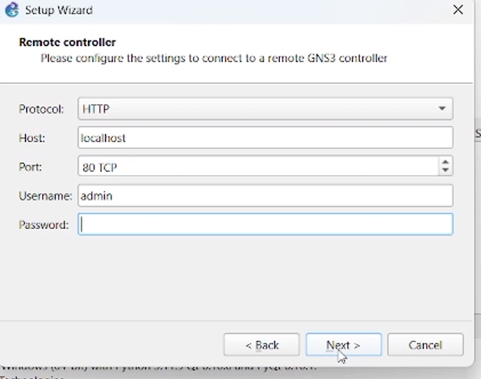

В мастере настройки указаны протокол HTTP, хост localhost, порт 80 TCP, логин admin.

## Создание нового проекта.

Создать новый проект в GNS3 через меню File → New blank project и назвать его, например, network.

[figure not shown]

В окне создания проекта введено имя «network».

## Импорт образа FRR.

Импортировать в GNS3 образ маршрутизатора FRR. В окне выбора файлов указать версию FRR, например FRR version 8.2.2, и нажать Next.

[figure not shown]

В списке версий FRR выбрана версия 8.2.2 со статусом Ready to install..

## Настройка шаблона FRR.

Настроить образ маршрутизатора FRR. В окне конфигурации шаблона во вкладке General settings в поле «On close» выбрать Send the shutdown signal (ACPI).

[figure not shown]

В настройках шаблона FRR указаны RAM 256 МБ, vCPUs 1, Boot priority HDD, On close — Send the shutdown signal (ACPI).

## Импорт образа VyOS.

Импортировать в GNS3 образ маршрутизатора VyOS. В окне выбора файлов указать версию VyOS Universal Router version 1.3.3 и нажать Import

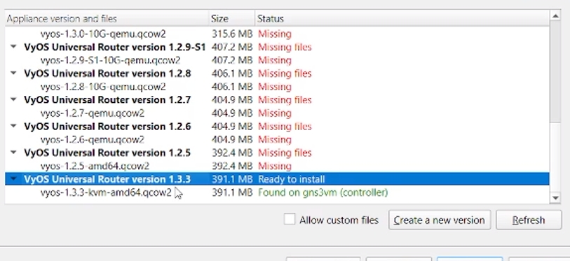

В списке версий VyOS выбрана версия 1.3.3 со статусом Ready to install.

## Проверка работы FRR.

Проверить корректность работы маршрутизатора FRR. В терминале должно появиться приглашение frr#, после чего ввести команду show version.

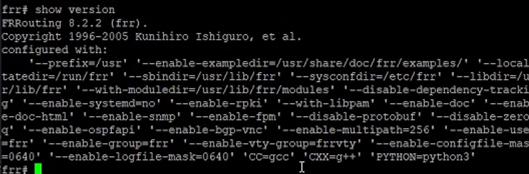

В терминале FRR выполнена команда show version, показана версия FRRouting 8.2.2.

## Проверка работы FRR и VyOS.

Проверить корректность работы маршрутизаторов FRR и VyOS. Убедиться, что оба устройства запущены и доступны через консоль.

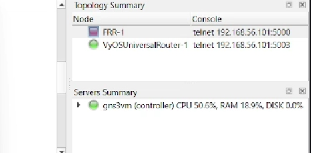

В Topology Summary отображаются узлы FRR-1 и VyOSUniversalRouter-1 с адресами консолей.

## Выводы

В ходе работы были установлены GNS3-all-in-one и GNS3 VM, проверена корректность их запуска. Освоены импорт и настройка образов маршрутизаторов FRR и VyOS, а также проверка их работоспособности через консоль. Получены практические навыки подготовки экспериментального стенда для эмуляции компьютерных сетей.